# COVID-19 Data Acquisition

05/01/2021

## Part 1: Data Science, and Epidemiology!

## So, what can we gain through the expanding use of Data Science in Epidemiology?

- Gain visibility to gather specific data.
- Statistics can plan and assess the required public health response.
- Data science aids in efficient future planning.
- RECAP: ‘R’ provides a quick and easy yielding of R libraries to analyze outbreak!

## Case 1: Taiwan’s proactive control towards COVID-19 (1)

- Taiwan: Constant alert, ready to act on epidemics arising from China ever since the SARS Epidemic (2003).
- Mobilized: case identification, containment, and resource allocation.
- Leveraged: National health insurance database, providing big data for analytics.

## Case 1: Taiwan’s proactive control towards COVID-19 (2)

- Real-time alerts based on travel history aided clinical visits.
- New Technology: QR code scanning and online reporting.

[figure not shown]

Taiwan’s Model for combating COVID-19

## Recognizing the Crisis:

- National Health Command Center (NHCC) was established in 2004 after SARS
- Unified a Central command system including: Central Epidemic Command Center (CECC), Biological Pathogen Disaster Command Center (BPDCO), Counter-Bioterrorism command center, and he Central Meical Emergency Operations Center.
- WHO notified of unknown pneumonia on 31st December 2019.
- January 20th: Taiwan Centers for Disease Control (CDC) activated the CECC

## Taiwan; proving the precious time-value of using Data Science (1)

- January 27: National Health Insurance Administration (NHIA) & the National Immigration Agency integrated patients’ last 14-day travel history.
- January 30: NHIA expanded their database to include data of travelers from China, Hong Kong and Macaw.
- February 14: Launch of “Entry Quarantine System”, completing health declaration by scanning a QR code. This system was created within 72 hours.

## Taiwan; proving the precious time-value of using Data Science (2)

- February 18: Government officially announced that pharmacies, hospitals and clinics have access to all patients’ travel histories.

[figure not shown]

Epidemic curve of weekly cases, comparing Taiwan to New Zealand

## Part 2: How sure can we be, that our data is accurate?

## Incidence Data by John Hopkins University (JHU)

- Widely used source that collates data from governmental websites
- Factors such as time-zone differences can be taken into account
- Time-series format, making results more efficient

## It’s possible that:

- Epidemiologists want to remove the number of people on board from the collated data for a particular period of time with assumptions such as:
- They were quarantined; decreasing the likeliness to exponentially increase the number of cases (there-on)
- Efficient evaluations can be made by epidemiologists to predict spreads and hotspots.

## Case 2: “Diamond Princess Cruise ship Case”

- Let’s assume this case as an example for data that we want to eliminate from our collated data.
- 712 people were infected with COVID-19 on the cruise ship.
- Quarantined for around two weeks.
- All passengers and crew members had finally disembarked the ship by March 1, 2020.

[figure not shown]

Diamond Princess Cruise Ship, February 2020

## What happened on the cruise ship?

- 14-day round trip that departed Yokohama on January 20, 2020.
- Screening for the virus took place on board the ship.
- Positive cases increased, confirming that the ship would remain quarantined.
- Once the quarantine period was over, people who were cleared of the illness were free to leave the ship. All of the 2,666 guests aboard the Diamond Princess had disembarked by February 27, 2020, and the final group of crew members left the ship a few days later.

## When in doubt, it’s always possible to compare data!

## Imporant note! Pay attention to the time-value of results:

- To receive efficient results, JHU’s results must be shifted back by one day.
- Why? As original dates are with respect to the Greenwich Time (Midnight UTC)
- This is efficient for combining our JHU and Wikipedia results, by referring to the local US time zones

## Comparing Results: Provided by JHU

- Aim: searching for COVID-19 cases in the USA from start (zero cases) to 5th March 2020.
- Excluding the Diamond Princess Cruise Ship
- Needed: R package

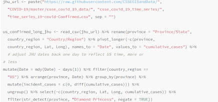

Coding with R

## Limited information:

[figure not shown]

JHU data; Covid Cases from start to 5th March 2020

## Comparing Results: Provided by Wikipedia

- Being created with several tables, we will have to Leverage on a new package to collate tabular data.
- Data Wrangling: A method used to convert the tabular data into a usable format
- A recommended package to be used: “rvest” package (Part of “tidyverse”).
- R can be used to quickly group and analyze data into tabular and graphical format.
- Focus: Particular period of time from beginning (Zero Cases) to the 5th March 2020.

## Implementing the comparision:

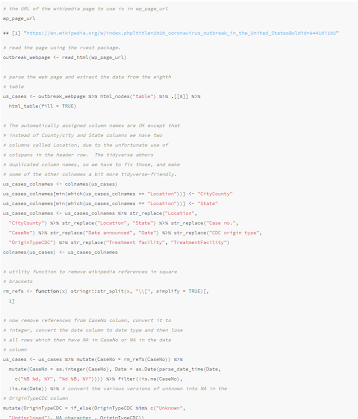

Coding with R once again

## Tabular results:

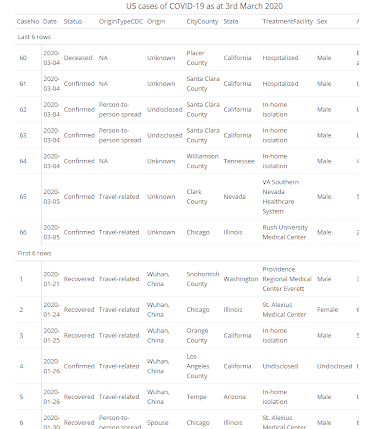

Clean results shown on R

## Results of comparing JHU and Wikipedia’s data in graphical format:

[figure not shown]

COVID19 incident cases in USA

## Part 3: Can we predict the Future with Data Science?

## A.) How many cases will there be in the next 10 days?

- Link: https://covid19forecast.science.unimelb.edu.au/
- Provides estimates of the COVID-19 growth rate and near-future case in each country.
- Updated daily based on the global data collated by Johns Hopkins University.

[figure not shown]

How many Cases will there be in the next 10 days?

## B.) Channel News Asia and understanding the “Red Dots”

- Link: https://infographics.channelnewsasia.com/covid-19/map.html
- Channel News Asia used its proficiency in data collection by creating a live count for confirmed cases, reported deaths and recovered patients.
- Interactive and user-friendly dashboard

[figure not shown]

[figure not shown]

## C.) US COVID ATLAS; a journey through time.

- Link: https://geodacenter.github.io/covid/
- A quick-assess county-level clustering surveillance tool
- Provides longitudinal exploration, and statistical cluster detection.
- Statistical hotspots: Supports surveillance and decision-making.

[figure not shown]

[figure not shown]

## References (1)

CNA. 2020. COVID-19 Map: Tracking The Coronavirus Outbreak Worldwide. [online] Available at: https://infographics.channelnewsasia.com/covid-19/map.html [Accessed 31 December 2020].

Corona Virus 10-day forecast. 2020. [online] Available at: https://covid19forecast.science.unimelb.edu.au/ [Accessed 26 December 2020].

Dahl, E., 2020. Coronavirus (Covid-19) outbreak on the cruise ship Diamond Princess. International Maritime Health, 71(1), pp.5-8.

Geodacenter.github.io. 2020. The US Covid Atlas. [online] Available at: https://geodacenter.github.io/covid/ [Accessed 24 December 2020].

## References (2)

Huang, L., Li, L., Dunn, L. and He, M., 2020. Taking Account of Asymptomatic Infections in Modeling the Transmission Potential of the COVID-19 Outbreak on the Diamond Princess Cruise Ship. SSRN Electronic Journal,.

Qian, X., 2020. Visualize The Pandemic With R #COVID-19. [online] Medium. Available at: https://towardsdatascience.com/visualize-the-pandemic-with-r-covid-19-c3443de3b4e4 [Accessed 8 December 2020].

Rasskin, N., 2020. COVID-19 Visualizer. [online] Covidvisualizer.com. Available at: https://www.covidvisualizer.com/ [Accessed 31 December 2020].

Sedkaoui, S. and Khelfaoui, M., 2019. Understand, develop and enhance the learning process with big data. Information Discovery and Delivery, 47(1), pp.2-16.

## References (3)

Soetewey, A., 2020. Top 100 R Resources On Novel COVID-19 Coronavirus. [online] Stats and R. Available at: https://www.statsandr.com/blog/top-r-resources-on-covid-19-coronavirus/ [Accessed 16 December 2020].

Studio, R., 2020. COVID-19 Epidemiology With R. [online] Rviews.rstudio.com. Available at: https://rviews.rstudio.com/2020/03/05/covid-19-epidemiology-with-r/ [Accessed 8 December 2020].

Worldometers.info. 2020. Coronavirus Update (Live): 83,425,633 Cases And 1,818,921 Deaths From COVID-19 Virus Pandemic - Worldometer. [online] Available at: https://www.worldometers.info/coronavirus/ [Accessed 31 December 2020].